# S8_Extra_GSE106118

Enrique Audain Martinez

2026-09-18

```r
# Packages used anywhere in this lesson. All of them are installed by
# setup/install_r.R.
library(tidyverse)
library(matrixStats)
```

```r
library(pheatmap)
library(RColorBrewer)
library(openxlsx)

# Paths (relative to this .Rmd, as in S2-S4)
expr_file <- "../../data/GSE106118_HE10W.tsv.gz"  # or .csv
out_dir   <- "outputs"
if (!dir.exists(out_dir)) dir.create(out_dir, recursive = TRUE)
```

```r
# Helper: read by extension
read_expr <- function(path){
  ext <- tolower(tools::file_ext(path))
  if (ext == "csv") readr::read_csv(path, show_col_types = FALSE)
  else readr::read_tsv(path, show_col_types = FALSE)
}

raw_df <- read_expr(expr_file)

# If copy/paste or wrapping introduced whitespace/newlines in column names:
fix_names <- function(x){
  x <- gsub("\\s+", "", x)     # remove spaces/newlines/tabs
  x <- gsub("\\.+", ".", x)    # squash repeated dots
  x
}

names(raw_df) <- fix_names(names(raw_df))
stopifnot("Gene" %in% names(raw_df))

# Convert to matrix (rows=genes, cols=samples)
expr_mat <- raw_df %>%
  dplyr::distinct(Gene, .keep_all = TRUE) %>%   # drop duplicated gene rows if any
  tibble::column_to_rownames("Gene") %>%
  as.matrix()

mode(expr_mat) <- "numeric"
dim(expr_mat); expr_mat[1:3, 1:6]
```

```
## [1] 24153   193
```

```
##          LA1 LA2 LA3 LA4 LA5 LA6
## A1BG       0   0   0   0   0   0
## A1BG-AS1   0   0   0   0   0   0
## A1CF       0   0   0   0   0   0
```

```r
sample_ids <- colnames(expr_mat)

meta <- tibble::tibble(
  sample   = sample_ids,
  chamber  = sub("^([A-Z]{2}).*$", "\\1", sample_ids),   # LA, LV, RA, RV
  replicate = readr::parse_number(sample_ids)
)

table(meta$chamber)
```

```
##
## LA LV RA RV
## 48 48 49 48
```

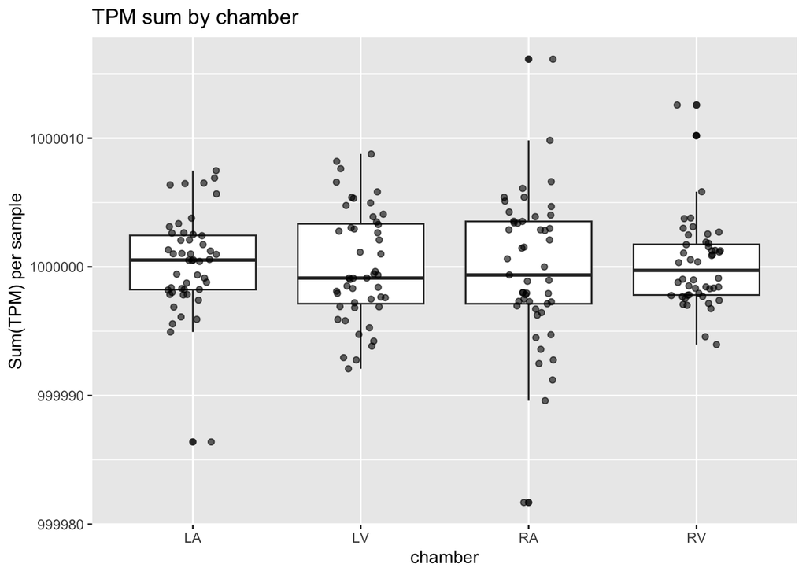

```r
lib_sums <- colSums(expr_mat, na.rm = TRUE)
qc <- tibble::tibble(sample = names(lib_sums), tpm_sum = lib_sums) %>%
  dplyr::left_join(meta, by = "sample")

ggplot(qc, aes(chamber, tpm_sum)) +
  geom_boxplot() + geom_jitter(width = 0.15, alpha = 0.6) +
  labs(title = "TPM sum by chamber", y = "Sum(TPM) per sample")
```

```r
keep <- rowSums(expr_mat > 1) >= 2
table(keep)
```

```
## keep
## FALSE  TRUE
##  7243 16910
```

```r
expr_f <- expr_mat[keep, , drop = FALSE]
dim(expr_mat); dim(expr_f)
```

```
## [1] 24153   193
```

```
## [1] 16910   193
```

```r
log1p_tpm <- log1p(expr_f)

# simple ranking: top 10 by mean expression
top_idx <- order(rowMeans(log1p_tpm), decreasing = TRUE)[1:10]
top_genes <- rownames(log1p_tpm)[top_idx]
tibble::tibble(Gene = top_genes, mean_log1p = rowMeans(log1p_tpm[top_genes, ]))
```

```
## # A tibble: 10 × 2
##    Gene   mean_log1p
##    <chr>       <dbl>
##  1 MYL7         9.35
##  2 FTH1         8.65
##  3 ACTC1        8.52
##  4 EEF1A1       8.47
##  5 TPM1         8.43
##  6 MYL6         8.31
##  7 RPLP1        8.27
##  8 GAPDH        8.25
##  9 TMSB10       8.19
## 10 HSPB1        8.18
```

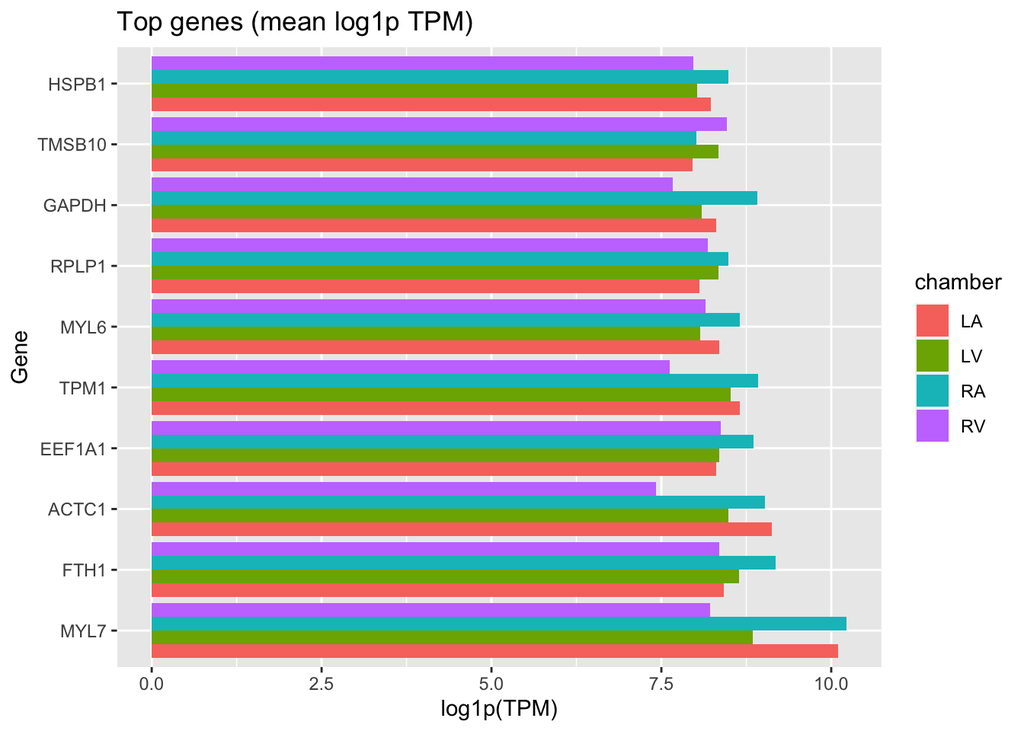

```r
top_long <- tibble::as_tibble(log1p_tpm[top_genes, ], rownames = "Gene") %>%
  tidyr::pivot_longer(-Gene, names_to = "sample", values_to = "log1p_tpm") %>%
  dplyr::left_join(meta, by = "sample")

ggplot(top_long, aes(reorder(Gene, -log1p_tpm), log1p_tpm, fill = chamber)) +
  stat_summary(fun = mean, geom = "col", position = position_dodge()) +
  coord_flip() +
  labs(title = "Top genes (mean log1p TPM)", x = "Gene", y = "log1p(TPM)")
```

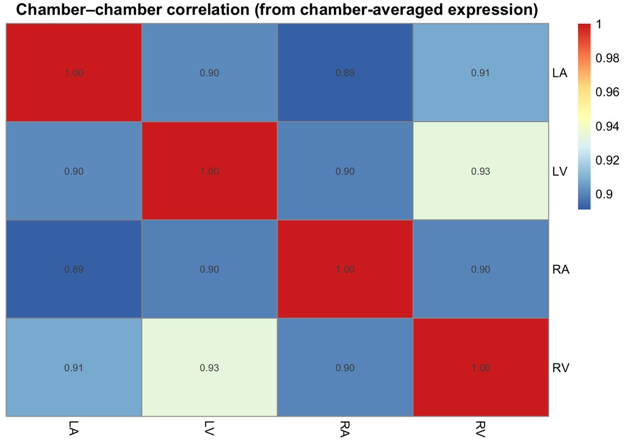

```r
### Chamber-averaged expression → chamber–chamber correlation (tidyverse)

# 1) Build a gene × chamber matrix of mean expression (using log1p TPM)
#    - Average each gene across samples within a chamber
gene_chamber_means <- tibble::as_tibble(log1p_tpm, rownames = "Gene") %>%
  tidyr::pivot_longer(-Gene, names_to = "sample", values_to = "log1p_tpm") %>%
  dplyr::left_join(meta %>% dplyr::select(sample, chamber), by = "sample") %>%
  dplyr::group_by(Gene, chamber) %>%
  dplyr::summarise(mean_log1p = mean(log1p_tpm, na.rm = TRUE), .groups = "drop") %>%
  tidyr::pivot_wider(names_from = chamber, values_from = mean_log1p)

# 2) Convert to a numeric matrix with genes as rows, chambers as columns
chamber_means_mat <- gene_chamber_means %>%
  tibble::column_to_rownames("Gene") %>%
  as.matrix()

# 3) Correlate chambers across genes (4×4)
#    - Pearson on log1p scale; change to method="spearman" if preferred
avg_cor_mat <- cor(chamber_means_mat, use = "pairwise.complete.obs", method = "pearson")

# 4) Plot the 4×4 chamber–chamber correlation heatmap
pheatmap(avg_cor_mat,
         display_numbers = TRUE,
         number_format = "%.2f",
         cluster_rows = FALSE,
         cluster_cols = FALSE,
         main = "Chamber–chamber correlation (from chamber-averaged expression)")
```

```r
# --- Identify chamber-biased genes -----------------
grp_means <- tibble::as_tibble(log1p_tpm, rownames = "Gene") %>%
  tidyr::pivot_longer(-Gene, names_to = "sample", values_to = "log1p_tpm") %>%
  dplyr::left_join(meta, by = "sample") %>%
  dplyr::group_by(Gene, chamber) %>%
  dplyr::summarise(mean_log1p = mean(log1p_tpm), .groups = "drop") %>%
  tidyr::pivot_wider(names_from = chamber, values_from = mean_log1p)

# Example contrasts:
# LA vs RA (atria)
atrial <- grp_means %>%
  dplyr::mutate(delta_LA_RA = LA - RA,
         abs_delta = abs(delta_LA_RA)) %>%
  dplyr::arrange(dplyr::desc(abs_delta))

head(atrial %>% dplyr::select(Gene, LA, RA, delta_LA_RA), 12)
```

```
## # A tibble: 12 × 4
##    Gene             LA    RA delta_LA_RA
##    <chr>         <dbl> <dbl>       <dbl>
##  1 ABCC9        6.61    2.92        3.69
##  2 L2HGDH       5.50    1.85        3.65
##  3 LOC100129434 6.24    2.90        3.34
##  4 LOC102724699 6.76    3.45        3.32
##  5 INMT         4.76    1.48        3.27
##  6 PARP15       5.66    2.42        3.24
##  7 ORC4         5.23    2.06        3.17
##  8 METTL21A     6.48    3.31        3.16
##  9 FOXK1        6.91    3.79        3.13
## 10 MYH7         1.55    4.61       -3.07
## 11 IFNG         0.0614  3.12       -3.06
## 12 LPP          6.47    3.41        3.06
```

```r
# LV vs RV (ventricles)
ventricular <- grp_means %>%
  dplyr::mutate(delta_LV_RV = LV - RV,
         abs_delta = abs(delta_LV_RV)) %>%
  dplyr::arrange(dplyr::desc(abs_delta))

head(ventricular %>% dplyr::select(Gene, LV, RV, delta_LV_RV), 12)
```

```
## # A tibble: 12 × 4
##    Gene      LV    RV delta_LV_RV
##    <chr>  <dbl> <dbl>       <dbl>
##  1 LYZ    6.16  1.75         4.41
##  2 MPO    5.23  0.951        4.28
##  3 SPP1   1.17  4.70        -3.52
##  4 CCL4   0.337 3.08        -2.74
##  5 CCL3   0.472 3.09        -2.61
##  6 CXCL8  1.22  3.83        -2.61
##  7 MT3    3.72  1.16         2.57
##  8 IL1B   0.485 3.04        -2.56
##  9 PLAC8  2.76  0.365        2.39
## 10 RRM2   3.02  0.640        2.38
## 11 CXCL2  0.606 2.99        -2.38
## 12 S100A9 2.75  0.369        2.38
```

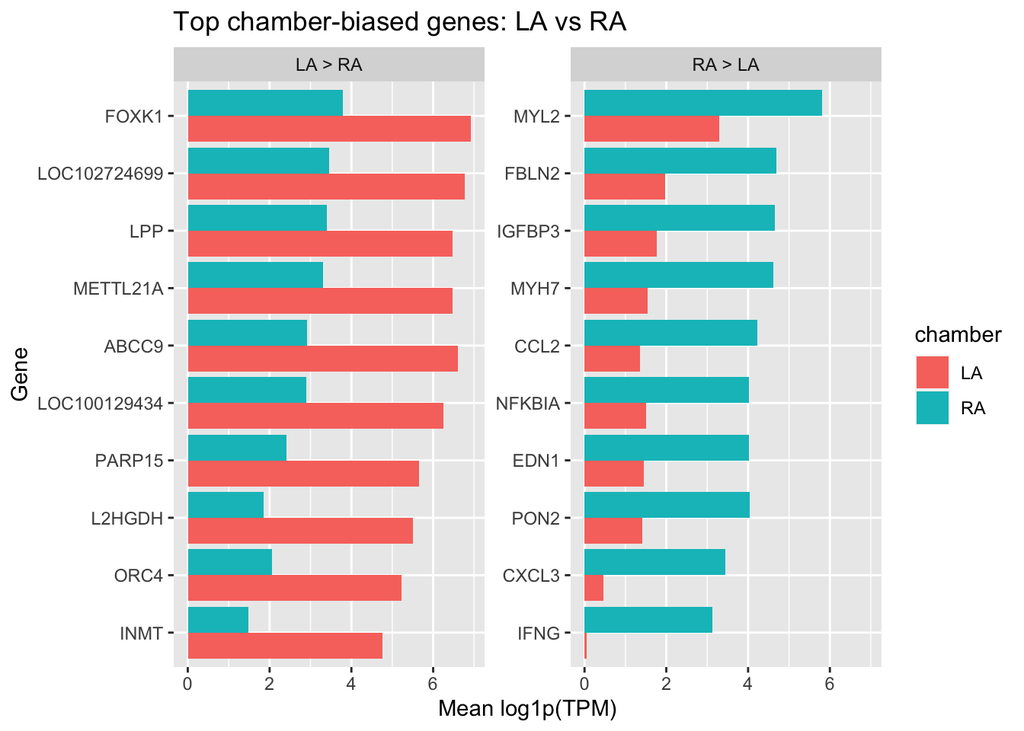

```r
# --- Plot top chamber-biased genes -----------------
plot_bias <- function(tbl, grpA, grpB, delta_col, title){
  top_bias <- dplyr::bind_rows(
    tbl %>% dplyr::slice_max(.data[[delta_col]], n = 10) %>% dplyr::mutate(direction = paste0(grpA," > ",grpB)),
    tbl %>% dplyr::slice_min(.data[[delta_col]], n = 10) %>% dplyr::mutate(direction = paste0(grpB," > ",grpA))
  )
  top_long <- top_bias %>%
    dplyr::select(Gene, dplyr::all_of(c(grpA, grpB)), direction) %>%
    tidyr::pivot_longer(cols = dplyr::all_of(c(grpA, grpB)), names_to = "chamber", values_to = "mean_log1p")
  ggplot(top_long, aes(reorder(Gene, mean_log1p), mean_log1p, fill = chamber)) +
    geom_col(position = "dodge") + coord_flip() +
    facet_wrap(~direction, scales = "free_y") +
    labs(title = title, x = "Gene", y = "Mean log1p(TPM)")
}

plot_bias(atrial, "LA", "RA", "delta_LA_RA", "Top chamber-biased genes: LA vs RA")
```

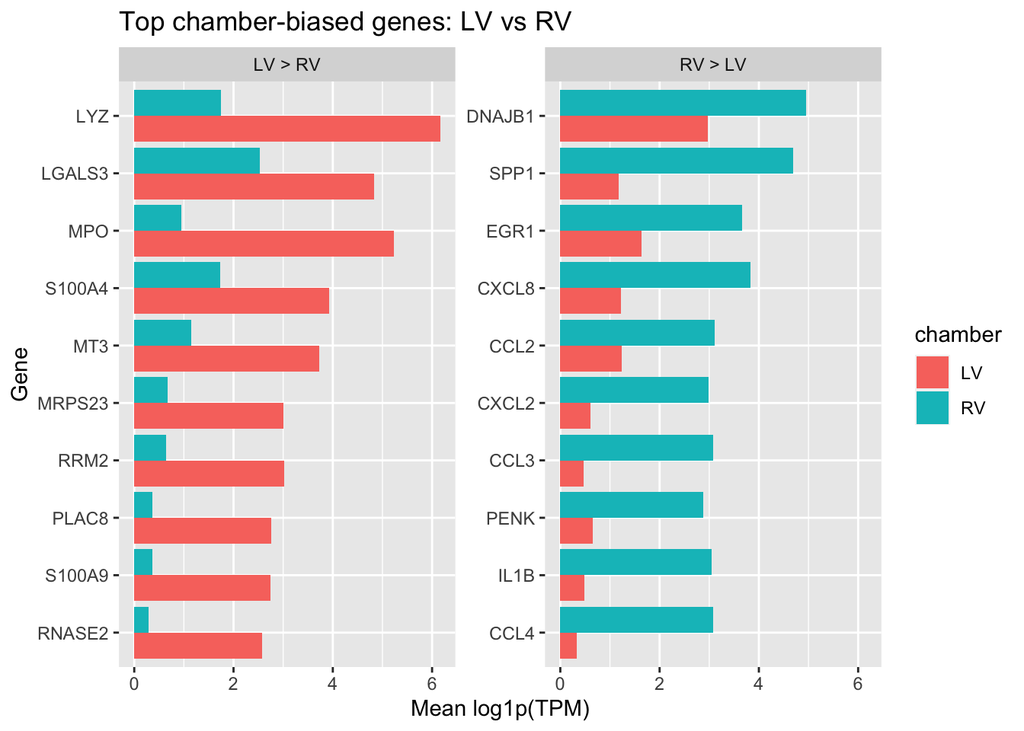

```r
plot_bias(ventricular, "LV", "RV", "delta_LV_RV", "Top chamber-biased genes: LV vs RV")
```

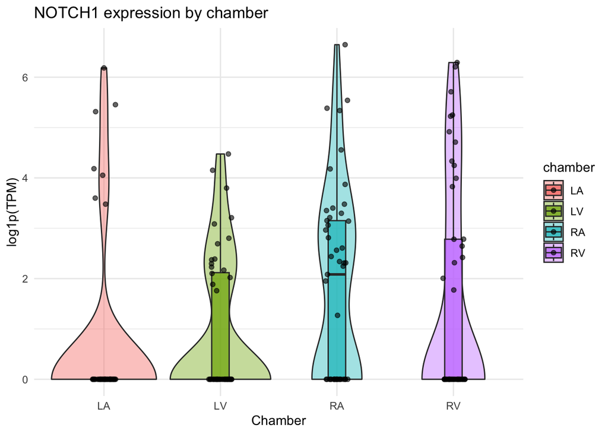

```r
### Expression of a single gene across chambers (example: NOTCH1)
gene_to_plot <- "NOTCH1"

# Extract gene values from log1p TPM matrix
gene_vals <- tibble::tibble(
  sample = colnames(log1p_tpm),
  value  = as.numeric(log1p_tpm[gene_to_plot, ])
) %>%
  dplyr::left_join(meta, by = "sample")

# 1) Violin + jitter + boxplot overlay
ggplot(gene_vals, aes(x = chamber, y = value, fill = chamber)) +
  geom_violin(trim = TRUE, alpha = 0.4) +
  geom_boxplot(width = 0.15, outlier.shape = NA, alpha = 0.7) +
  geom_jitter(width = 0.1, alpha = 0.6, size = 1.5) +
  labs(title = paste(gene_to_plot, "expression by chamber"),
       x = "Chamber", y = "log1p(TPM)") +
  theme_minimal()
```

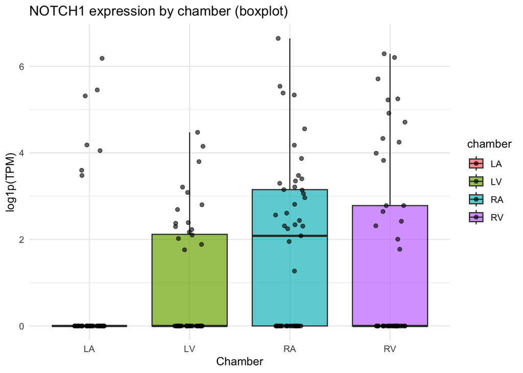

```r
# 2) Plain boxplot + jitter
ggplot(gene_vals, aes(x = chamber, y = value, fill = chamber)) +
  geom_boxplot(outlier.shape = NA, alpha = 0.7) +
  geom_jitter(width = 0.15, alpha = 0.6, size = 1.5) +
  labs(title = paste(gene_to_plot, "expression by chamber (boxplot)"),
       x = "Chamber", y = "log1p(TPM)") +
  theme_minimal()
```

```r
### Pairwise comparisons of NOTCH1 expression across chambers

gene_to_test <- "NOTCH1"

# Extract gene values (log1p TPM) + chamber labels
gene_vals <- tibble::tibble(
  sample = colnames(log1p_tpm),
  value  = as.numeric(log1p_tpm[gene_to_test, ])
) %>%
  dplyr::left_join(meta, by = "sample") %>%
  dplyr::filter(!is.na(chamber))

# Pairwise Wilcoxon rank-sum test with BH adjustment
pw <- pairwise.wilcox.test(gene_vals$value,
                           gene_vals$chamber,
                           p.adjust.method = "BH",
                           exact = FALSE)

# Tidy output: group1, group2, p_adj
pw_df <- tibble::as_tibble(pw$p.value, rownames = "group1") %>%
  tidyr::pivot_longer(-group1, names_to = "group2", values_to = "p_adj") %>%
  tidyr::drop_na() %>%
  dplyr::mutate(gene = gene_to_test) %>%
  dplyr::arrange(p_adj)

pw_df
```

```
## # A tibble: 6 × 4
##   group1 group2   p_adj gene
##   <chr>  <chr>    <dbl> <chr>
## 1 RA     LA     0.00278 NOTCH1
## 2 RA     LV     0.0269  NOTCH1
## 3 RV     LA     0.0366  NOTCH1
## 4 LV     LA     0.149   NOTCH1
## 5 RV     RA     0.293   NOTCH1
## 6 RV     LV     0.298   NOTCH1
```

```r
#--- 1) Calculate average expression per chamber -----------------
chamber_means <- tibble::as_tibble(log1p_tpm, rownames = "Gene") %>%
  tidyr::pivot_longer(-Gene, names_to = "sample", values_to = "log1p_tpm") %>%
  dplyr::left_join(meta, by = "sample") %>%
  dplyr::group_by(Gene, chamber) %>%
  dplyr::summarise(mean_expr = mean(log1p_tpm), .groups = "drop")

#--- 2) Select top N unique genes per chamber --------------------
topN <- 50   # <-- adjust as needed

top_per_chamber <- chamber_means %>%
  dplyr::group_by(chamber) %>%
  dplyr::arrange(dplyr::desc(mean_expr), .by_group = TRUE) %>%
  dplyr::slice_head(n = topN) %>%
  dplyr::ungroup()

# Peek
table(top_per_chamber$chamber)
```

```
##
## LA LV RA RV
## 50 50 50 50
```

```r
#--- 3) Split by chamber and write to Excel ----------------------
wb <- createWorkbook()

for (ch in unique(top_per_chamber$chamber)) {
  df <- top_per_chamber %>% dplyr::filter(chamber == ch) %>% dplyr::select(Gene, mean_expr)
  addWorksheet(wb, sheetName = ch)
  writeData(wb, sheet = ch, df)
}

saveWorkbook(wb, file = file.path(out_dir, "TopGenes_perChamber.xlsx"), overwrite = TRUE)
```

## Capstone exercise: enrichment of chamber-specific genes

This exercise applies the workflow from S6 to the human fetal heart data. The genes are already human symbols, so no ortholog mapping is required. Use Enrichr (https://maayanlab.cloud/Enrichr/) with **GO Biological Process 2025**.

### Step 1 — build two gene lists

```r
dir.create(out_dir, showWarnings = FALSE)

# List A: the most highly expressed genes in the left atrium.
list_A <- top_per_chamber %>%
  dplyr::filter(chamber == "LA") %>%
  dplyr::pull(Gene)

# List B: the 50 genes most strongly biased towards LA over RA.
# This is one-directional: genes higher in RA than LA are not included.
# Step 5 takes both directions for the ventricles.
list_B <- atrial %>%
  dplyr::slice_max(delta_LA_RA, n = 50) %>%
  dplyr::pull(Gene)

writeLines(list_A, file.path(out_dir, "LA_top_expressed.txt"))
writeLines(list_B, file.path(out_dir, "LA_biased.txt"))

# Number of genes shared by the two lists
length(intersect(list_A, list_B))
```

```
## [1] 2
```

### Step 2 — run the enrichment

Submit each list to Enrichr and download the GO Biological Process 2025 table. Before looking at the results, note what you expect each list to return.

### Step 3 — compare the results

- How do the enriched terms differ between the two lists?
- Which list is better suited to identifying differences between chambers, and why?
- Highly expressed genes tend to be similar across tissues. What does this imply for using “most highly expressed” as the input to enrichment?
- What background gene set does Enrichr use, and is it appropriate for either list?

### Step 4 — inspect the genes behind the terms

For the more informative list, examine the `Genes` column of the top five terms (see S6, section 8).

- Is any term driven mainly by a single gene family?
- Do several terms share most of their genes?
- Is any term name inconsistent with the tissue studied?

Summarise the results you consider supported, and list the terms you excluded with the reason for excluding each.

### Step 5 — optional: ventricles

Repeat the analysis for the ventricles using `ventricular` and `delta_LV_RV`, and compare the results with those for the atria.

```r
list_LV <- ventricular %>% dplyr::slice_max(delta_LV_RV, n = 50) %>% dplyr::pull(Gene)
list_RV <- ventricular %>% dplyr::slice_min(delta_LV_RV, n = 50) %>% dplyr::pull(Gene)

writeLines(list_LV, file.path(out_dir, "LV_biased.txt"))
writeLines(list_RV, file.path(out_dir, "RV_biased.txt"))
```